# Revised Assignment 5: Exercise in Data Visualization_20161019

Oscar Feng-Hsun Chang

In this assignment, I used baseball statistic data downloaded from [FanGraphs website](http://www.fangraphs.com) simply because I’m interested in baseball. This data include the following statistics of all the starting pitchers in the past 30 seasons (1986-2016).

- W: game won
- L: game lost
- G: game played
- GS: game played as the starter
- IP: inning played in the whole season
- K9: strike out produced per 9 innings
- BB9: Balls produced per 9 innings
- BABIP: how many of a batter’s balls in play go for hits, excluding home runs
- LOB: Left on Base percentage, the percentage of base runners that a pitcher strands on base over the course of a season
- HRFB: Home Run to Fly Ball rate, ratio of how many home runs are hit against a pitcher for every fly ball they allow
- FIP: Fielding Independent Pitching, what a player??s ERA would look like over a given period of time if the pitcher were to have experienced league average results on balls in play and league average timing
- WAR: Wins Above Replacement, an attempt by the sabermetric baseball community to summarize a player’s total contributions to their team in one statistic
- WHIP: Walks plus Hits per Innings Pitched, measures how many base runners a pitcher lets up
- ERA: Earned Run Average, calculated by dividing a pitcher??s total number of Earned Runs allowed by his total number of Innings Pitched and multiply by nine
- Age: the pitcher’s age at the season

### Loading packages and data

First, I loaded the packages that are needed in my further analyses. Note that I use dplyr (I think dplyr is a special version of plyr that is designed specifically for data frame) and tidyr instead of plyr and reshape2. However, in order to demonstrate that I can manage reshape2 package, I duplicate some of my code in two packages.

> Just use whichever you prefer: there is no need to do the same thing twice.

```r
library(ggplot2)
library(dplyr)
library(tidyr)
library(plyr)
library(reshape2)
library(RCurl)
```

Now, load the data and skim the data type and data structure.

```r
AL_SP=read.csv(text=getURL("https://raw.githubusercontent.com/OscarFHC/EEB480_ModelInfer_assignment/master/Mod_Infer_hw5_EDA/MLB_AL_SP_1986_2016.csv"), sep=",", header=T, comment.char="#")

str(AL_SP)
```

```
## 'data.frame':    4600 obs. of  19 variables:
##  $ Season: int  1986 1986 1987 1988 1989 1998 1999 1999 1999 1999 ...
##  $ Name  : Factor w/ 1414 levels "A.J. Burnett",..: 1272 442 205 1271 749 620 26 997 1296 925 ...
##  $ Team  : Factor w/ 17 levels "Angels","Astros",..: 8 8 12 13 4 13 1 17 16 10 ...
##  $ W     : int  0 1 0 1 0 0 0 0 0 0 ...
##  $ L     : int  0 0 0 0 0 0 0 0 0 0 ...
##  $ G     : int  1 1 1 1 1 1 1 1 1 1 ...
##  $ GS    : int  1 1 1 1 1 1 1 1 1 1 ...
##  $ IP    : num  3 5 7 6 3 6 4 4 6 6 ...
##  $ K9    : num  6 5.4 14.1 6 18 ...
##  $ BB9   : num  0 1.8 0 3 0 1.5 0 2.25 3 0 ...
##  $ HR9   : num  0 0 0 0 0 0 0 0 0 0 ...
##  $ BABIP : num  0.25 0.214 0.231 0.3 0 0.267 0.231 0.2 0.222 0.286 ...
##  $ LOB   : num  1 1 1 1 1 1 1 1 1 1 ...
##  $ HRFB  : num  NA NA NA NA NA NA NA NA NA NA ...
##  $ FIP   : num  2.44 2.17 -0.27 2.44 -1.24 1.64 2.13 2.38 3.47 -0.87 ...
##  $ WAR   : num  0.1 0.2 0.6 0.2 0.2 0.3 0.2 0.2 0.2 0.5 ...
##  $ WHIP  : num  0.67 0.8 0.43 1.33 0 0.83 0.75 0.75 1 0.33 ...
##  $ ERA   : num  0 0 0 0 0 0 0 0 0 0 ...
##  $ Age   : int  29 23 25 31 25 23 31 32 28 24 ...
```

```r
head(AL_SP)
```

```
##   Season             Name      Team W L G GS IP    K9 BB9 HR9 BABIP LOB
## 1   1986   Steve Fireovid  Mariners 0 0 1  1  3  6.00 0.0   0 0.250   1
## 2   1986      Edwin Nunez  Mariners 1 0 1  1  5  5.40 1.8   0 0.214   1
## 3   1987 Calvin Schiraldi   Red Sox 0 0 1  1  7 14.14 0.0   0 0.231   1
## 4   1988       Steve Farr    Royals 1 0 1  1  6  6.00 3.0   0 0.300   1
## 5   1989       Jose Nunez Blue Jays 0 0 1  1  3 18.00 0.0   0 0.000   1
## 6   1998      Jeff Suppan    Royals 0 0 1  1  6  9.00 1.5   0 0.267   1
##   HRFB   FIP WAR WHIP ERA Age
## 1   NA  2.44 0.1 0.67   0  29
## 2   NA  2.17 0.2 0.80   0  23
## 3   NA -0.27 0.6 0.43   0  25
## 4   NA  2.44 0.2 1.33   0  31
## 5   NA -1.24 0.2 0.00   0  25
## 6   NA  1.64 0.3 0.83   0  23
```

> Don’t show this to your reader unless you want them to see it. If you want a record of these procedures, hide them from the reader using chunk option `include=FALSE`.

Now use *arrange* function to sort the data first by Season(year) then by team and Pitcher’s name, so that it looks nicer.

```r
AL_SP = AL_SP %>% arrange(Season, Team, Name)
head(AL_SP)
```

```
##   Season            Name   Team  W  L  G GS    IP   K9  BB9  HR9 BABIP
## 1   1986      Don Sutton Angels 15 11 34 34 207.0 5.04 2.13 1.35 0.246
## 2   1986      Jim Slaton Angels  3  6 12 12  64.0 3.66 3.94 1.27 0.299
## 3   1986 John Candelaria Angels 10  2 16 16  91.2 7.95 2.55 0.39 0.255
## 4   1986  Kirk McCaskill Angels 17 10 33 33 244.1 7.40 3.39 0.70 0.271
## 5   1986       Mike Cook Angels  0  1  1  1   3.0 3.00 6.00 0.00 0.417
## 6   1986       Mike Witt Angels 18 10 34 34 269.0 6.96 2.44 0.74 0.256
##     LOB HRFB  FIP WAR WHIP   ERA Age
## 1 0.753   NA 4.35 2.2 1.16  3.74  41
## 2 0.600   NA 5.19 0.1 1.63  6.33  36
## 3 0.733   NA 2.52 3.0 1.03  2.55  32
## 4 0.738   NA 3.33 5.5 1.22  3.39  25
## 5 0.286   NA 4.10 0.0 2.33 12.00  22
## 6 0.756   NA 3.14 6.7 1.08  2.84  25
```

### Answering couple easy questions

```r
ALSP.all = AL_SP %>%
           filter(IP>1 & GS>1)
ALSP.all2 = AL_SP %>%
           subset(IP>1 & GS>1)

allSP = length(unique(ALSP.all$Name))
allSP
```

```
## [1] 1276
```

> Comments? What do you compare this figure to?

## 2.Does a pitcher win or lose more games across the past 30 seasons?

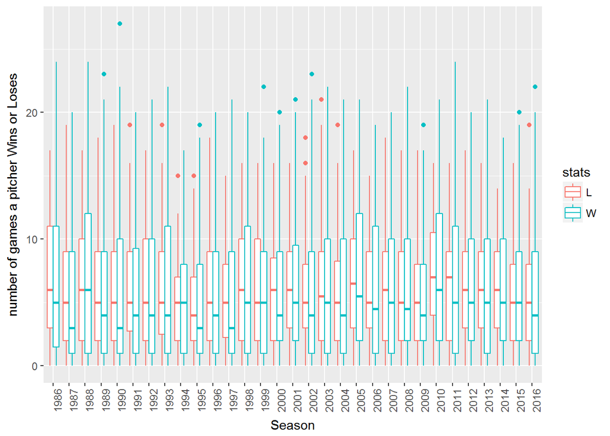

```r
ALSP.all.long = ALSP.all %>%
                gather(key=stats, value=val, W, L, G, GS, IP, K9, BB9, HR9, BABIP, LOB, HRFB, FIP, WAR, WHIP, ERA, Age)

ggplot(data=ALSP.all.long[which(ALSP.all.long$stats=="W"|ALSP.all.long$stats=="L"),],
       aes(x=factor(Season), y=val, color=stats),
       group=stats)+
  geom_boxplot(position="dodge")+ #self note, postition argument by default is "dodge"
  theme(axis.text.x=element_text(angle = 90, hjust=1))+
  xlab("Season")+
  ylab("number of games a pitcher Wins or Loses")
```

> What does this plot tell us? Why do we care about the distribution of wins/losses for a given year?

Supprisingly, on average, a pitcher tend to loss more than win a game, although the differences are not significant. This is probably due to the statistical artifact of this stats that losing a game is a little bit easier than winning a game. To be recorded as a losing pitcher, a pitcher only needs to allow a run which gives the opposing team the lead regardless how many innings that pitcher pitched. But to be recorded as a winning pitcher, a pitcher has to pitch at least 5 innings if the pitcher is the starting pitcher.

## 3.What is the relationship between ERA (Earned Run Average) and the Win-loss ratio and does this relationship change with IP (number of Inning Pitched).

To make the win-loss ratio comparable, I divided the ratio by the IP. I also divide the pitcher’s into 3 arbitrary groups according to the IP (<50, 50-100, >100)

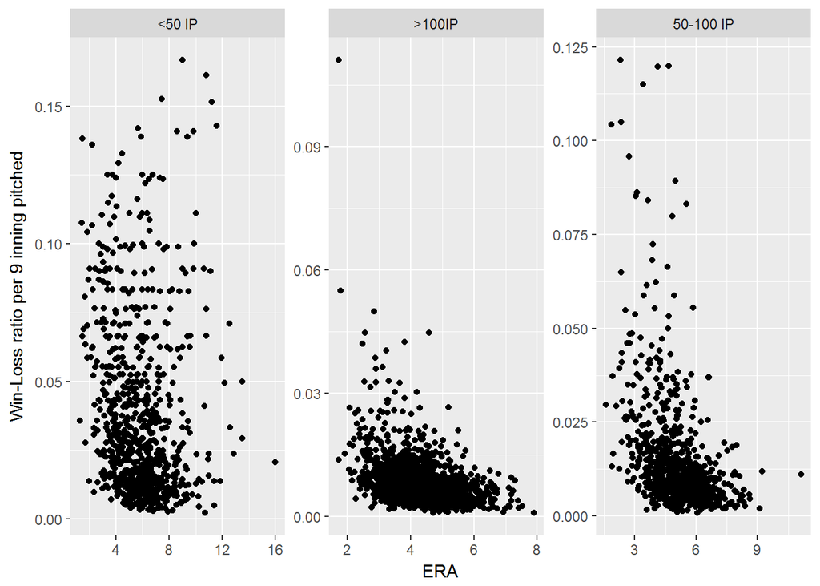

To me, this reveals two things. First, giving up more runs does not necessary means losing more, which could make sense as winning a game requires not just allowing less runs but also batting in more runs. Second, the relationship between Win-Loss ratio and ERA, if there is any, looks non-linear, which is even more interesting!

- Couple questions here.
1. The scale of x-axis is fixed even I used the “scales=”free" " argument in the `facet_grid()` function, so I have to use `facet_wrap()`.

> Yes, but is that a question?
2. If I’m interested to see how the relationship change with IP, I guess I should do a 3D plot or a contour instead of a arbitrary grouping. The following code gives me warning message saying “Computation failed in `stat_contour()`: dimensions of ‘x’, ‘y’ and ‘z’ do not match” But the dimension of the x, y, and z are the same. Please see the following code.

> The data need to be in a grid format for `geom_contour`. Perhaps try binning the data?

```r
ggplot(data=ALSP.WL, aes(x=ERA, y=WL9, z=IP))+
  geom_contour(binwidth = 0.001)+
  xlab("ERA")+
  ylab("Win-Loss ratio per 9 inning pitched")
```

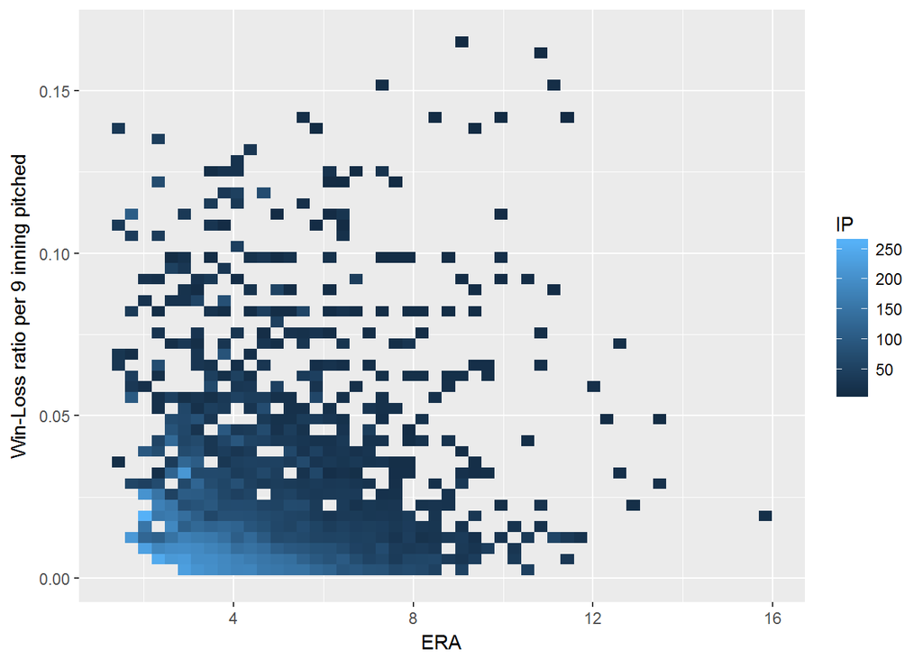

```r
ERA.breaks <- with(ALSP.WL,seq(from=min(ERA),to=max(ERA),length=51))
WL9.breaks <- with(ALSP.WL,seq(from=min(WL9),to=max(WL9),length=51))
ALSP.WL %>%
  mutate(
    ERA.bin=cut(ERA,breaks=ERA.breaks,include=TRUE,ordered=TRUE),
    WL9.bin=cut(WL9,breaks=WL9.breaks,include=TRUE,ordered=TRUE)
  ) %>%
  mutate(
    ERA=mapvalues(as.numeric(ERA.bin),from=seq_len(50),
                  to=head(ERA.breaks,-1)+0.5*diff(ERA.breaks)),
    WL9=mapvalues(as.numeric(WL9.bin),from=seq_len(50),
                  to=head(WL9.breaks,-1)+0.5*diff(WL9.breaks))
    ) %>%
  ddply(~ERA.bin+WL9.bin,summarize,
        ERA=mean(ERA),WL9=mean(WL9),IP=mean(IP)) %>%
  ggplot(aes(x=ERA, y=WL9, z=IP))+
  geom_tile(aes(fill=IP))+
  # geom_contour(binwidth = 0.001)+
  xlab("ERA")+
  ylab("Win-Loss ratio per 9 inning pitched")
```

## 4. What is the relationship between BABIP (should reflect how many hit a pitcher allowed per balls in play) and ERA (Earned Run Average) and how does this relationship change with IP.

[figure not shown]

```r
ggplot(data=ALSP.WL, aes(x=ERA, y=BABIP),
       group=IP.id)+
    geom_point()+
    stat_smooth(method="lm")+
    facet_wrap(~IP.id, nrow=1, scales="free")+
    xlab("BABIP")+
    ylab("ERA")
```

There is a more clear positive relationship between BABIP and ERA, indicating that the more hit a pitcher allowed, the more runs the pitcher will allow. This relationship also seems to be different in each group of pitcher. Again, I can use contour plot to avoid arbitrary grouping.